# Classification of Immission Measurements(2)

Dr. Alf Loeffler

11/30/2021

## Classification of Immission Measurements 2000 to 2020 in Baden Wuerttemberg(BW)

### Periodicity of recorded data

The distribution of immissions depends on many factors:

- the time and intensity of operations,
- the location of the emission sources,
- the interaction of the atmospheric components and
- the effect of wind speed and direction on the dilution

A summary of state of the art calculation and simulation methods (Stand der Modellierungstechnik zur Prognose der NO2-Konzentrationen in Luftreinhalteplänen nach der 39. BImSchV) was published by the Umweltbundesamt and is available from [Stand Modellierung UBA](http://www.uba.de/uba-info-medien/4191.html)

### Location of emission sources

Exhaust gas from motor vehicles is emitted to a large extend along main routes (Autobahn, Bundesstrassen, Hauptstrassen).Statistics show, that about 50% are emitted outside urban area. Fuel burned for heating results in emissions spreads within settled areas. Power plants are located at a few points in BW. As their chimneys are high the exhaust gas is to some extend diluted when it reaches populated areas. Industrial emissions are mainly some distance off settled areas.

### Time dependence of emissions

> Emitters don’t work at constant rate at various times. Examples:
> - Burning fuel to heat is necessary if temperatures are less than 15 C, that is normally during winter month.Hence,automated house >heating systems are normally controlled by outside temperature or heat loss.
> - traffic with passenger cars is different at working days and weekends.  
>   This can be verified by analyzing the dependence of immissions at selected days of the week or hours of a day or combination of both

### Windeffects

> If the source of emissions (e.g. a power plant) is located in the direction of winds, the immissions depend on wind direction.  
> The windrose measured at the sampling station Reutlingen show sensitivity to emissions from the sector 105° to 135° and 225° to 255° which are the main wind directions.  
> Strong winds transport emissions over greater distance. The dependence of immission on the wind force and distance can be used to identify immission sources.

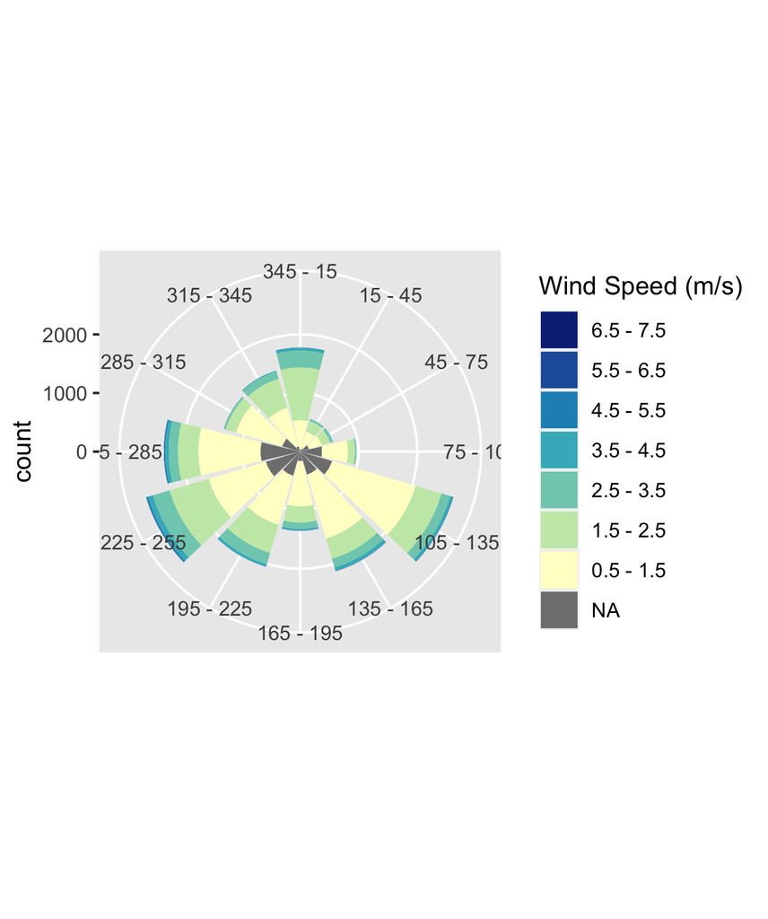

Reutlingen Windrose

## Pattern recognition in extended time series of measurements

In the first part of this publication we did show the long term trends of NO2-immissions at selected stations taking samples in urban and rural environments and how the trends depend on the long term trends of emission sources.

With this part we show how the periodic variation **monthly(or calendar week), day of the week, hour of the day** of emissions are related to immission variation at the sampling stations. This correlations can be used to identify the contributions of the various emissions sources to the measured immissions.

As an example of urban immissions we selected the station an Stuttgart Bad Cannstatt (ID 4452). Emissions effecting the local measurements come from

- **fossil fuel burned** > for heating and warming water,
- **vehicle exhaust**,
- **power plants**,
- **waste treatment**
- **industrial processes**

## Effects of heating on urban immissions

Heating to keep temperatures at living rooms at 20 C is necessary at outside temperatures (Temp) less than 15 C. The emissions from burning fossil fuels is proportional to $Grdz = (20 - Temp)*perc.time$.

| Gesamt.std | Hzg.std | perc.time | Temp.avg | Grdz |
| --- | --- | --- | --- | --- |
| 184103 | 121404 | 65.9 | 6.7 | 8.8 |

## Emissions from fuel burned for heating

# 20 years mean values

Heating bills of apartments show that about 20% of the fuel- burned for keeping the temperature of the rooms is needed for heating water.

# Anual data

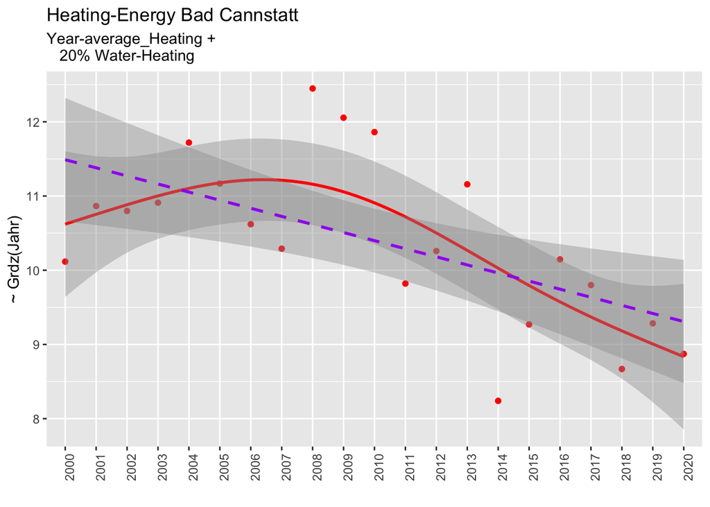